# working with igraph package

Maria Prokofieva

18/02/2021

### Working with `igraph`

2.1 Creating a network object in `igraph`

### Creating network objects in `igraph``

Let’s create an *undirected* graph with 3 edges: 1–>2, 2–>3, 3–>1.

```r
g1 <- graph(edges=c(1,2, 2,3, 3, 1), n=3, directed=F)
class(g1)
```

```
## [1] "igraph"
```

```r
g1
```

```
## IGRAPH 7cc0ae6 U--- 3 3 --
## + edges from 7cc0ae6:
## [1] 1--2 2--3 1--3
```

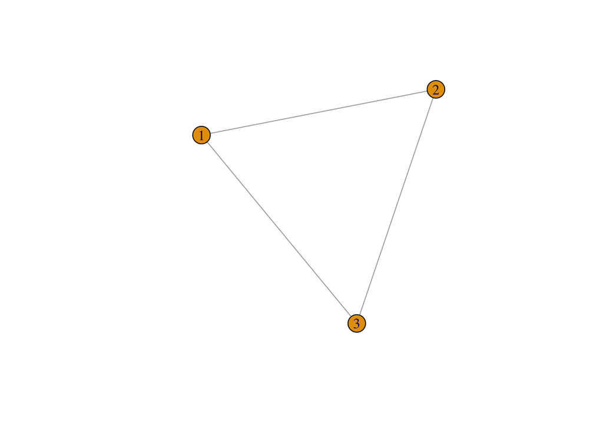

```r
plot(g1) # simple plot of the network
```

Let’s do more!

```r
g2 <- graph(edges=c(1,2, 2,3, 3, 1), n=10, directed=F)
class(g2)
```

```
## [1] "igraph"
```

```r
g2
```

```
## IGRAPH d7dcb0e U--- 10 3 --
## + edges from d7dcb0e:
## [1] 1--2 2--3 1--3
```

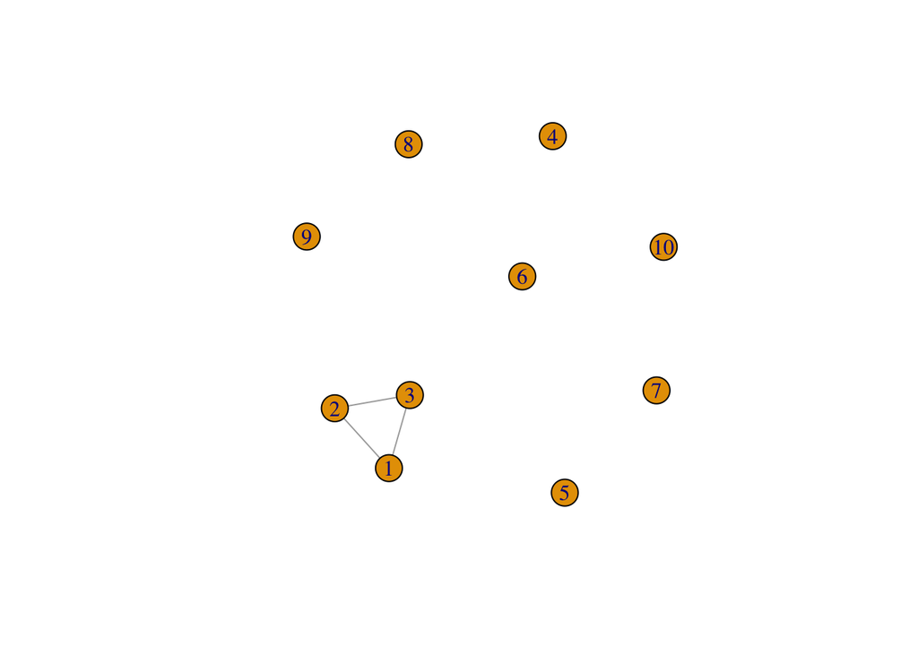

```r
plot(g2) # how does it look like?
```

Let’s move on to some specific graphs and graph models

**Empty graph**: `graph.empty` or `make_empty_graph`

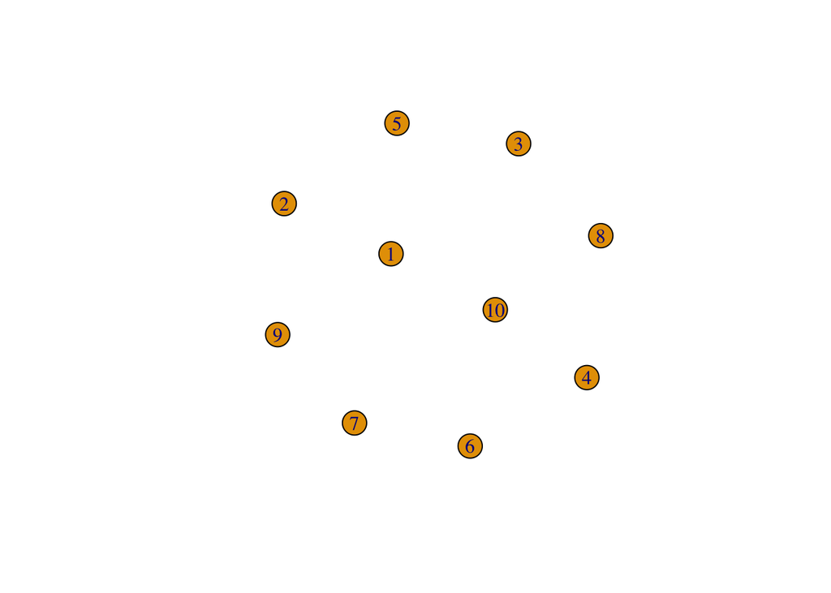

```r
g<-graph.empty(n=10, directed=TRUE)

#g<-make_empty_graph(n=10, directed=TRUE)
plot(g)
```

**Complete graph**: each pair of vertices has an edge connecting them, we use `LOOPS = FALSE` to not add self edges

We can use `graph.full` OR `make_full_graph`

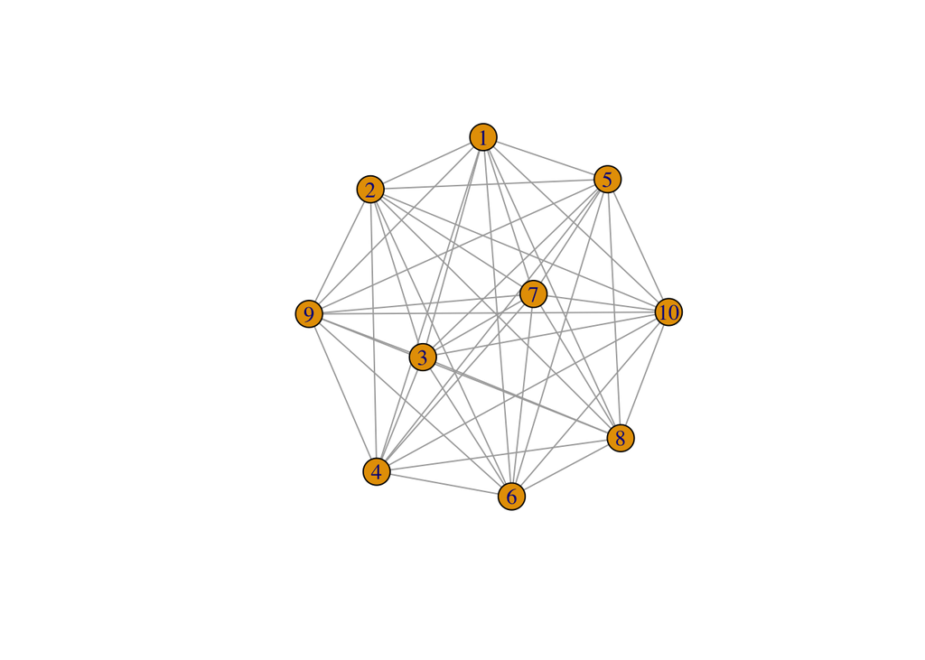

```r
g<-graph.full(n=10, directed = FALSE, loops = FALSE)
plot(g)
```

**Stars**

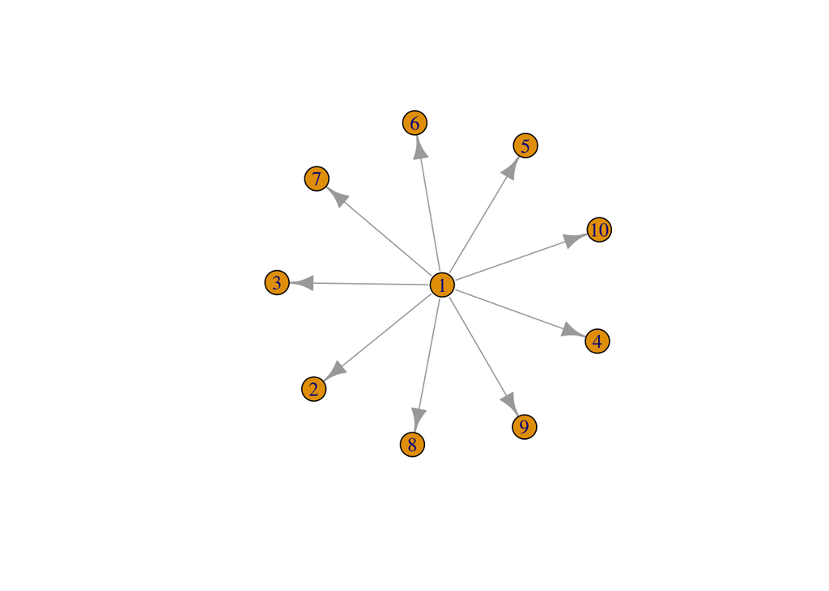

```r
g<-graph.star(n=10, mode="out") #or make_star()
plot(g)
```

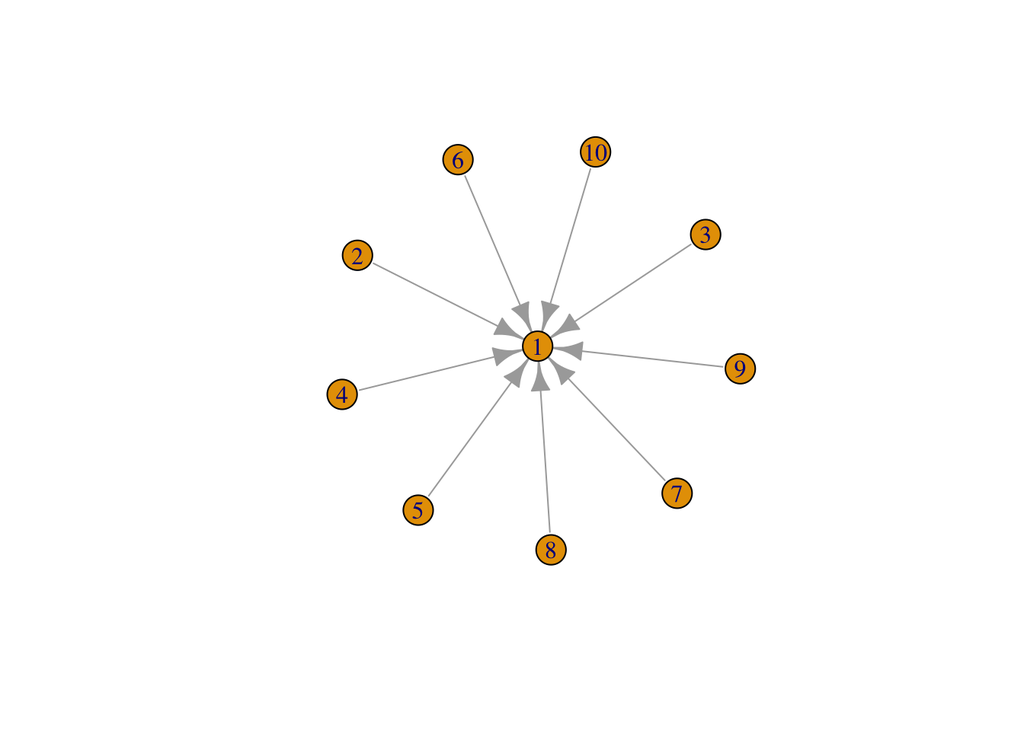

```r
g<-graph.star(n=10, mode="in")
plot(g)
```

**Rings**

```r
g<-graph.ring(n=10) #or make_ring()
```

**Task**:

- create a star graph with 7 vertices pointed to the center
- create a full directed graph with 12 vertices and no loops

`igraph` can also create some notable historical graphs, such as [Zachary carate club](https://en.wikipedia.org/wiki/Zachary%27s_karate_club)

```r
 zach <- graph("Zachary") # the Zachary carate club
zach
```

```
## IGRAPH 55cf7a8 U--- 34 78 -- Zachary
## + attr: name (g/c)
## + edges from 55cf7a8:
##  [1]  1-- 2  1-- 3  1-- 4  1-- 5  1-- 6  1-- 7  1-- 8  1-- 9  1--11  1--12
## [11]  1--13  1--14  1--18  1--20  1--22  1--32  2-- 3  2-- 4  2-- 8  2--14
## [21]  2--18  2--20  2--22  2--31  3-- 4  3-- 8  3--28  3--29  3--33  3--10
## [31]  3-- 9  3--14  4-- 8  4--13  4--14  5-- 7  5--11  6-- 7  6--11  6--17
## [41]  7--17  9--31  9--33  9--34 10--34 14--34 15--33 15--34 16--33 16--34
## [51] 19--33 19--34 20--34 21--33 21--34 23--33 23--34 24--26 24--28 24--33
## [61] 24--34 24--30 25--26 25--28 25--32 26--32 27--30 27--34 28--34 29--32
## [71] 29--34 30--33 30--34 31--33 31--34 32--33 32--34 33--34
```

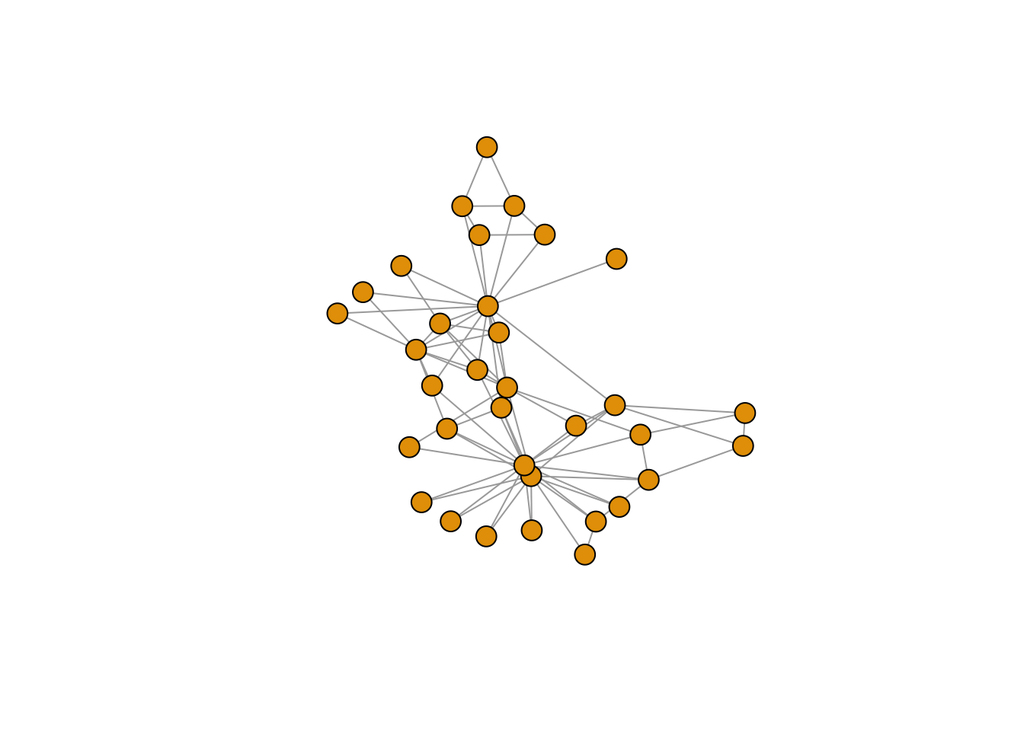

```r
 plot(zach, vertex.size=10, vertex.label=NA)
```

The description of the igraph object typically start with up to four letters:

`D` or `U`, for a directed or undirected graph

`N` for a named graph (where nodes have a name attribute)

`W` for a weighted graph (where edges have a weight attribute)

`B` for a bipartite (two-mode) graph (where nodes have a type attribute)

The two numbers that follow refer to the number of nodes and edges in the graph.

The description also lists graph, node & edge attributes, e.g.:

`(g/c)` - graph-level character attribute

`(v/c)` - vertex-level character attribute

`(e/n)` - edge-level numeric attribute

Now let’s create more “complicated” graphs with the given list of edges

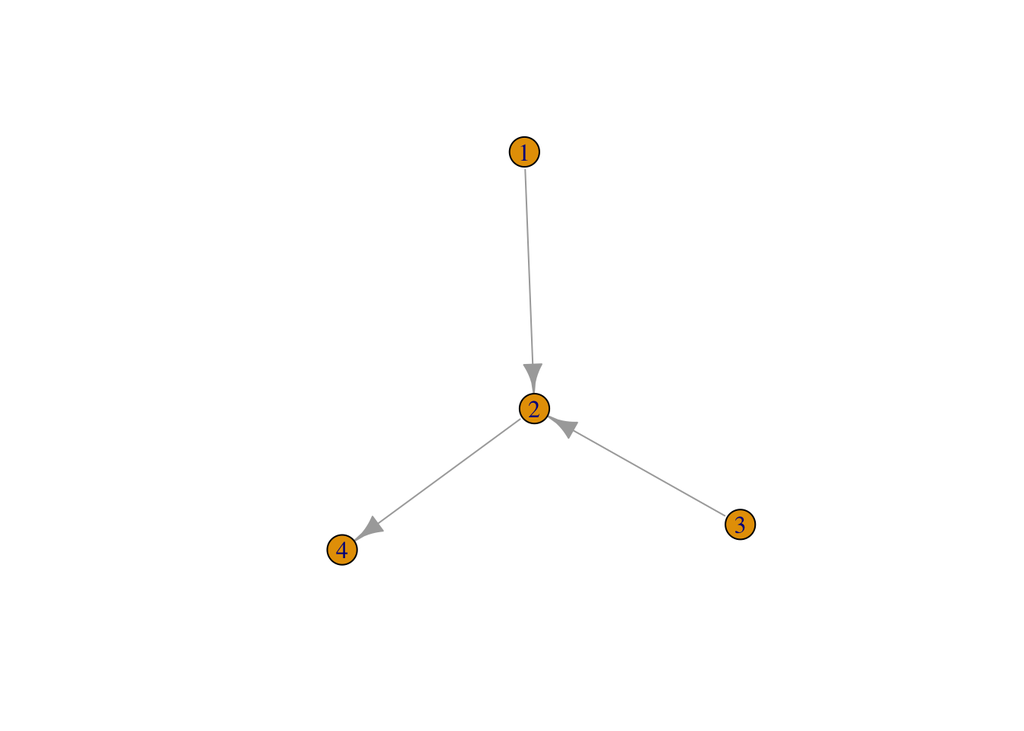

```r
edges <- c(1,2, 3,2, 2,4)
g<-graph(edges, n=max(edges), directed=TRUE)
plot(g)
```

Can we do a **named graph**? Sure we can!

When you use vertex names in your edge list, you don’t need the number of nodes

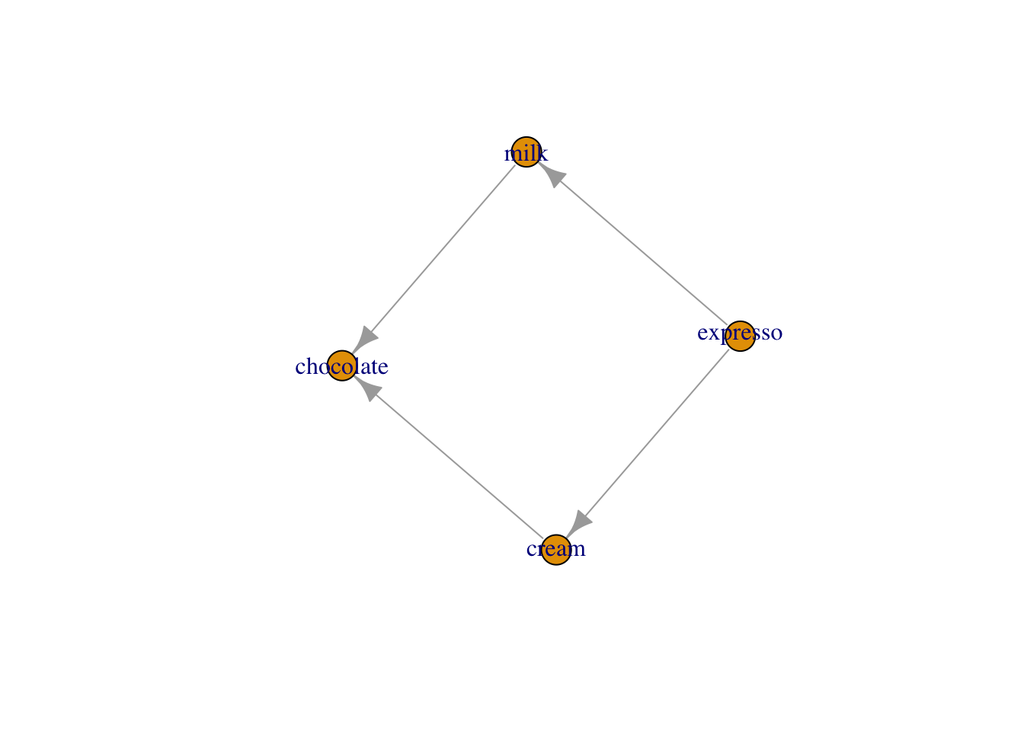

```r
g3 <- graph( c("expresso", "milk", "milk", "chocolate", "cream", "chocolate", "expresso", "cream")) # named vertices
plot(g3)
```

For smaller graphs we can use

- `-`for undirected tie,
- `+-` for pointing left or
- `-+` for directed ties & right,
- `++` for a symmetric tie, and
- “:” for sets of vertices.

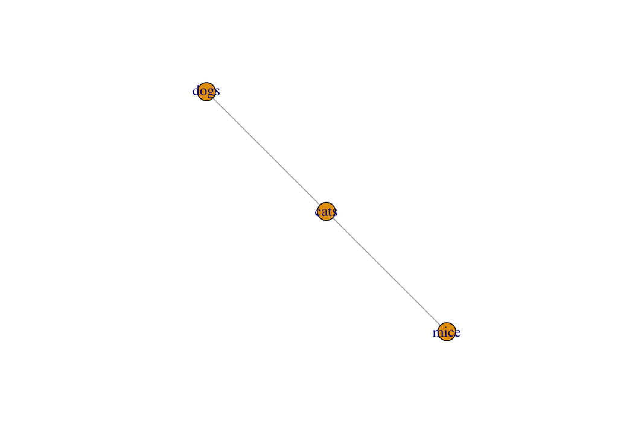

```r
plot(graph_from_literal("dogs"---"cats", "cats"---"mice")) # the number of dashes doesn't matter
```

**Task**

- create a named graph `family` with the nodes=your family members/relates/friends - try to keep it under 20!

Use the directed graph to show your family tree and connections

### Graph structure information

To access vertices and edges:

```r
E(g3) # The edges of the object
```

```
## + 4/4 edges from 228fd2b (vertex names):
## [1] expresso->milk      milk    ->chocolate cream   ->chocolate
## [4] expresso->cream
```

```r
V(g3) # The vertices of the object
```

```
## + 4/4 vertices, named, from 228fd2b:
## [1] expresso  milk      chocolate cream
```

To view the network in a matrix form

```r
g3[]
```

```
## 4 x 4 sparse Matrix of class "dgCMatrix"
##           expresso milk chocolate cream
## expresso         .    1         .     1
## milk             .    .         1     .
## chocolate        .    .         .     .
## cream            .    .         1     .
```

`vcount` and `ecount` return the number of vertex / number of edges

```r
edges <- c(1,2, 3,2, 1,4)
g<-graph(edges, n=max(edges), directed=TRUE)
vcount(g)
```

```
## [1] 4
```

```r
ecount(g)
```

```
## [1] 3
```

```r
neighbors(g, V(g)[1])
```

```
## + 2/4 vertices, from 39a64f2:
## [1] 2 4
```

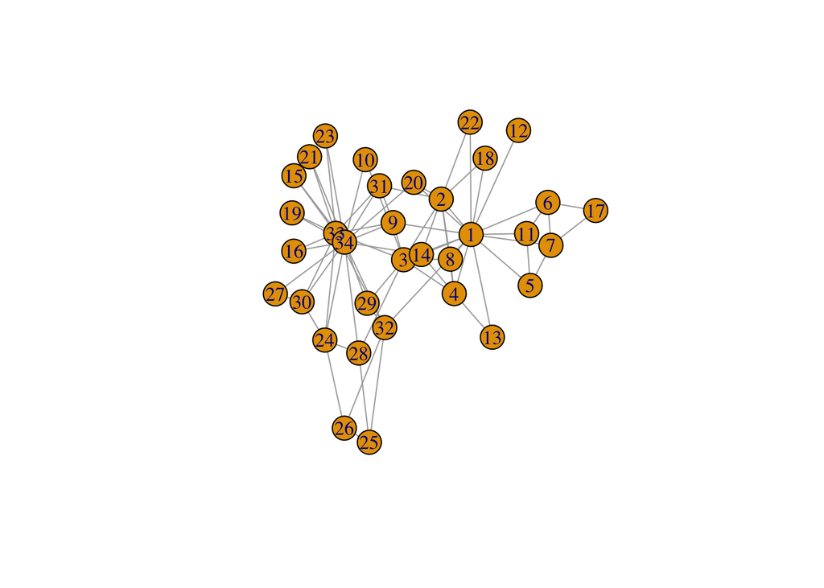

```r
zachary_graph <- make_graph("Zachary")
plot(zachary_graph)
```

```r
n17 <- neighbors(zachary_graph, 17)
n7 <- neighbors(zachary_graph, 7)
intersection(n17, n7)
```

```
## + 1/34 vertex, from 76e8a30:
## [1] 6
```

`is_directed`: directed/undirected type of graph

`are_adjacent`:is there a link between vertices v1 and v2 in graph

```r
is_directed(g)
```

```
## [1] TRUE
```

```r
are_adjacent(zachary_graph, n17, n7)
```

```
## [1] TRUE
```

`get.edgelist`: returns the list of edges in a graph.

```r
get.edgelist(g)
```

```
##      [,1] [,2]
## [1,]    1    2
## [2,]    3    2
## [3,]    1    4
```

`get.adjacency`: to get the adjacency matrix of a graph.

```r
get.adjacency(zachary_graph)
```

```
## 34 x 34 sparse Matrix of class "dgCMatrix"
##
##  [1,] . 1 1 1 1 1 1 1 1 . 1 1 1 1 . . . 1 . 1 . 1 . . . . . . . . . 1 . .
##  [2,] 1 . 1 1 . . . 1 . . . . . 1 . . . 1 . 1 . 1 . . . . . . . . 1 . . .
##  [3,] 1 1 . 1 . . . 1 1 1 . . . 1 . . . . . . . . . . . . . 1 1 . . . 1 .
##  [4,] 1 1 1 . . . . 1 . . . . 1 1 . . . . . . . . . . . . . . . . . . . .
##  [5,] 1 . . . . . 1 . . . 1 . . . . . . . . . . . . . . . . . . . . . . .
##  [6,] 1 . . . . . 1 . . . 1 . . . . . 1 . . . . . . . . . . . . . . . . .
##  [7,] 1 . . . 1 1 . . . . . . . . . . 1 . . . . . . . . . . . . . . . . .
##  [8,] 1 1 1 1 . . . . . . . . . . . . . . . . . . . . . . . . . . . . . .
##  [9,] 1 . 1 . . . . . . . . . . . . . . . . . . . . . . . . . . . 1 . 1 1
## [10,] . . 1 . . . . . . . . . . . . . . . . . . . . . . . . . . . . . . 1
## [11,] 1 . . . 1 1 . . . . . . . . . . . . . . . . . . . . . . . . . . . .
## [12,] 1 . . . . . . . . . . . . . . . . . . . . . . . . . . . . . . . . .
## [13,] 1 . . 1 . . . . . . . . . . . . . . . . . . . . . . . . . . . . . .
```

[output cut: 21 more lines]

**Task**

In the previous task you created the named graph `family` with the nodes=your family members/relates/friends:

- show the number of verices/edges in your graph
- display the edgelist and adjacency matrix

### Working with network attributes, edges and verteces

Compared to the matrix, network objects have the ability to store additional **attribute** information about the nodes and ties within the same network object.

Add attributes to the network, vertices, or edges:

```r
V(g3)$name # automatically generated when we created the network.
```

```
## [1] "expresso"  "milk"      "chocolate" "cream"
```

```r
V(g3)$calories <- c("high", "medium", "high", "high")
E(g3)$type <- "yumminess" # Edge attribute, assign "yumminess" to all edges
E(g3)$weight <- 10 # Edge weight, setting all existing edges to 10
```

To examine attributes:

```r
edge_attr(g3)
```

```
## $type
## [1] "yumminess" "yumminess" "yumminess" "yumminess"
##
## $weight
## [1] 10 10 10 10
```

```r
vertex_attr(g3)
```

```
## $name
## [1] "expresso"  "milk"      "chocolate" "cream"
##
## $calories
## [1] "high"   "medium" "high"   "high"
```

```r
graph_attr(g3)
```

```
## named list()
```

We can also set attributes using `set_edge_attr()`, `set_vertex_attr()`

```r
g3 <- set_graph_attr(g3, "calories", "yumminess")
g3 <- set_graph_attr(g3, "time of day", "time")

graph_attr_names(g3)
```

```
## [1] "calories"    "time of day"
```

```r
graph_attr(g3, "calories")
```

```
## [1] "yumminess"
```

```r
graph_attr(g3)
```

```
## $calories
## [1] "yumminess"
##
## $`time of day`
## [1] "time"
```

Let’s delete the attribute

```r
g3 <- delete_graph_attr(g3, "time of day")
graph_attr(g3)
```

```
## $calories
## [1] "yumminess"
```

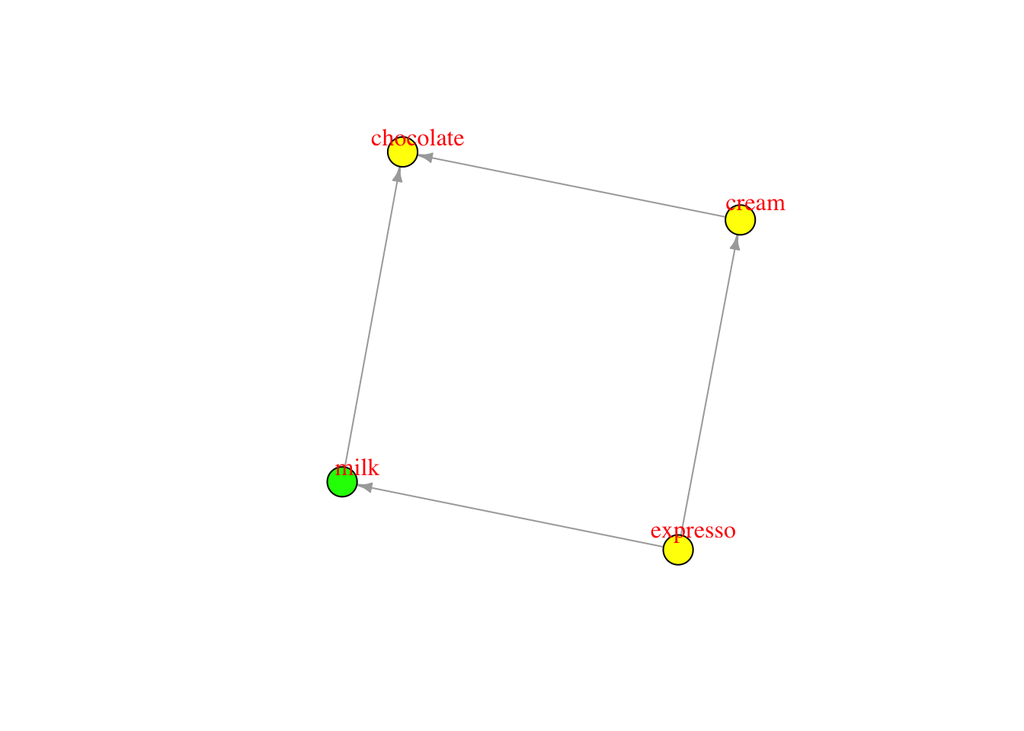

```r
plot(g3, edge.arrow.size=.5, vertex.label.color="red", vertex.label.dist=1.5,
     vertex.color=c("green", "yellow")[1+(V(g3)$calories=="high")] )
```

How can we `simplify` the graph using `edge.attr.comb` to combine edge attributes:

Options:

- `sum`, `mean`, `prod` (=product), `min`, `max`, `first`/`last` (selects the first/last edge’s attribute).
- `ignore` to disregard/drop the attribute

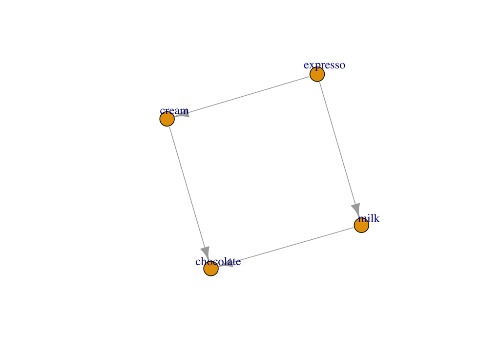

```r
g3_simplified <- simplify(g3, remove.multiple = T, remove.loops = F,
                 edge.attr.comb=list(weight="sum", type="ignore") )
plot(g3_simplified, vertex.label.dist=1.5)
```

```r
g3_simplified
```

```
## IGRAPH 5feace5 DNW- 4 4 --
## + attr: calories (g/c), name (v/c), calories (v/c), weight (e/n)
## + edges from 5feace5 (vertex names):
## [1] expresso->milk      expresso->cream     milk    ->chocolate
## [4] cream   ->chocolate
```

**Task**

In the previous task you created the named graph `family` with the nodes=your family members/relates/friends:

- add an attribute to vertices (e.g gender)
- add an attribute to edges specifying the type of relations (e.g. good, love, well_it_is_family)

## remove the last attribute you added to edges (they’d better not know!)

### Modifying the graph

You can change the graph by adding more vertices and/or edges

```r
add_edges(graph, edges, ..., attr=list())
add_vertices(graph, vertices, ..., attr=list())
```

Let’s create an empty graph and add edges and vertices to it. We will be adding an attribute `color` to edges and using a new value for `color` for new members.

```r
g <- make_empty_graph(n = 7) %>%
  add_edges(c(1,2, 2,3, 3,4, 4,5, 6,7)) %>%
  set_edge_attr("color", value = "green") %>%
  add_edges(c(5,1), color = "red")
E(g)[[]]
```

```
## + 6/6 edges from 0872923:
##   tail head tid hid color
## 1    1    2   1   2 green
## 2    2    3   2   3 green
## 3    3    4   3   4 green
## 4    4    5   4   5 green
## 5    6    7   6   7 green
## 6    5    1   5   1   red
```

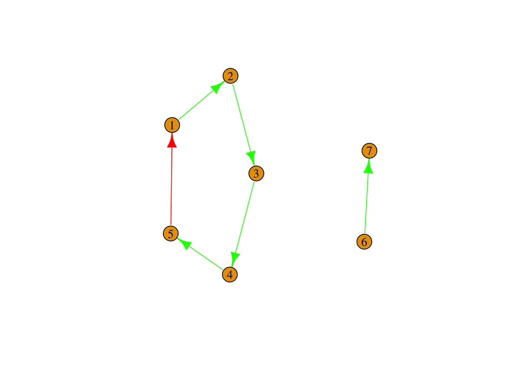

```r
plot(g)
```

Let’s do the same for vertices

```r
add_vertices(graph, nv, ..., attr = list())
```

where `nv` is the number of vertices to add

```r
g <- g %>%
  add_vertices(8, color = "pink") %>%
  add_vertices(9, color = "purple") %>%
  add_edges(c(7,8, 8,1, 9,1, 9,2))
g
```

```
## IGRAPH 8afe9a9 D--- 24 10 --
## + attr: color (v/c), color (e/c)
## + edges from 8afe9a9:
##  [1] 1->2 2->3 3->4 4->5 6->7 5->1 7->8 8->1 9->1 9->2
```

```r
V(g)[[]]
```

```
## + 24/24 vertices, from 8afe9a9:
##     color
## 1    <NA>
## 2    <NA>
## 3    <NA>
## 4    <NA>
## 5    <NA>
## 6    <NA>
## 7    <NA>
## 8    pink
## 9    pink
## 10   pink
## 11   pink
## 12   pink
## 13   pink
## 14   pink
## 15   pink
## 16 purple
## 17 purple
## 18 purple
## 19 purple
## 20 purple
## 21 purple
## 22 purple
## 23 purple
## 24 purple
```

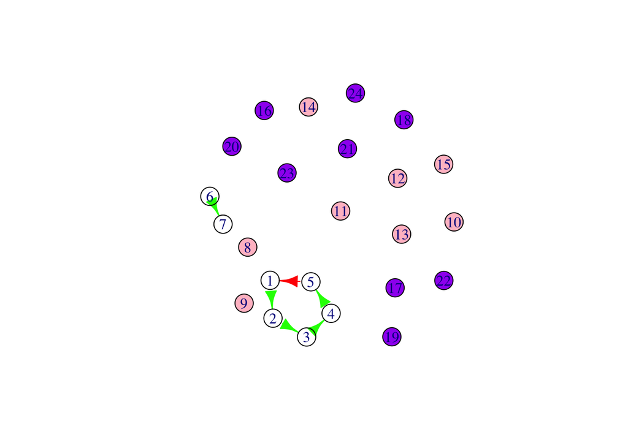

```r
plot(g)
```

### Graphs import / export

We are going to talk about importing graphs in more details when we are going to go through case studies. For now, you can use the following functions from `igraph`:

- `read.graph()` to load graph using edgelist
- `graph.adjacency()` from adjacency matrix: you can load your matrix using `read_csv()` (from `tidyverse`) to load the dataset, then convert it to a matrix using `as.matrix()` function and then using this matrix in `graph.adjacency()`
- `graph.data.frame()` to import from a dataframe/table

To export your graph you can use `write_graph()`to save it in different formats.

```r
write_graph(
  graph,
  file,
  format = c("edgelist", "pajek", "ncol", "lgl", "graphml", "dimacs", "gml", "dot",
    "leda")
)
```

**Task**

In the previous task you created the named graph `family` with the nodes=your family members/relates/friends:

Save your graph as a pdf file in your working directory -

### Graph visualization

Graph visualization is a HUGE topic and we are going to talk about that in details in the second half of the workshop

**Final tasks to summarize**

Create a ring graph with random number of vertex (between 10 and 15). *HINT* use `sample() function to generate the random number.

```r
sample(x, size, replace = FALSE, prob = NULL)
```

where

- `x` is a vector of elements to choose from
- `size` is a non-negative integer giving the number of items to choose.

*Solutions*

```r
n <-sample(10:15,1)

g <- graph.ring(n)

vcount(g)
```

```
## [1] 14
```

```r
ecount(g)
```

```
## [1] 14
```

```r
neighbors(g, 10)
```

```
## + 2/14 vertices, from 7877661:
## [1]  9 11
```

```r
incident(g, 10)
```

```
## + 2/14 edges from 7877661:
## [1]  9--10 10--11
```

```r
are.connected(g, 3, 10)
```

```
## [1] FALSE
```

```r
are.connected(g, 2, 5)
```

```
## [1] FALSE
```

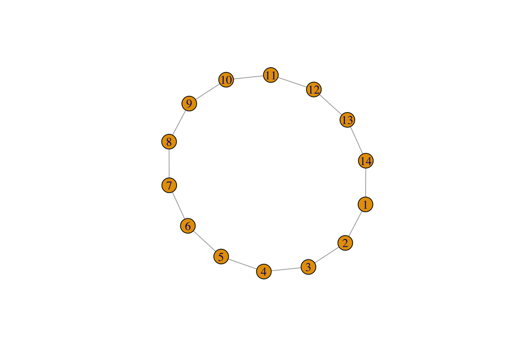

```r
plot(g, layout = layout.fruchterman.reingold,vertex.label=V(g)$number, edge.arrow.size=0.5)
```

Let’s do more:

*Solutions*

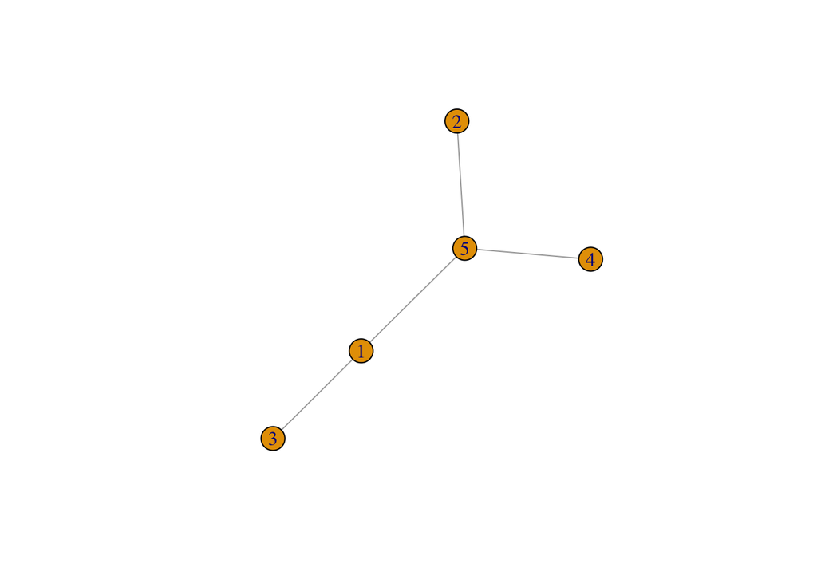

```r
g <- graph.empty (5, directed = FALSE)

new_edges <- c(1,3, 1,5, 2,5, 4,5)

g <- add_edges(g, new_edges)

plot(g)
```

```r
g <- add_vertices(g, 1)

g <- add_edges(g, c(6,5))

V(g)$name <- letters[1:vcount(g)]

E(g)$weight <- runif(ecount(g))

get.adjacency(g, attr="weight")
```

```
## 6 x 6 sparse Matrix of class "dgCMatrix"
##            a        b         c          d          e         f
## a .          .        0.9651705 .          0.02081151 .
## b .          .        .         .          0.71106297 .
## c 0.96517055 .        .         .          .          .
## d .          .        .         .          0.06365028 .
## e 0.02081151 0.711063 .         0.06365028 .          0.7846717
## f .          .        .         .          0.78467174 .
```

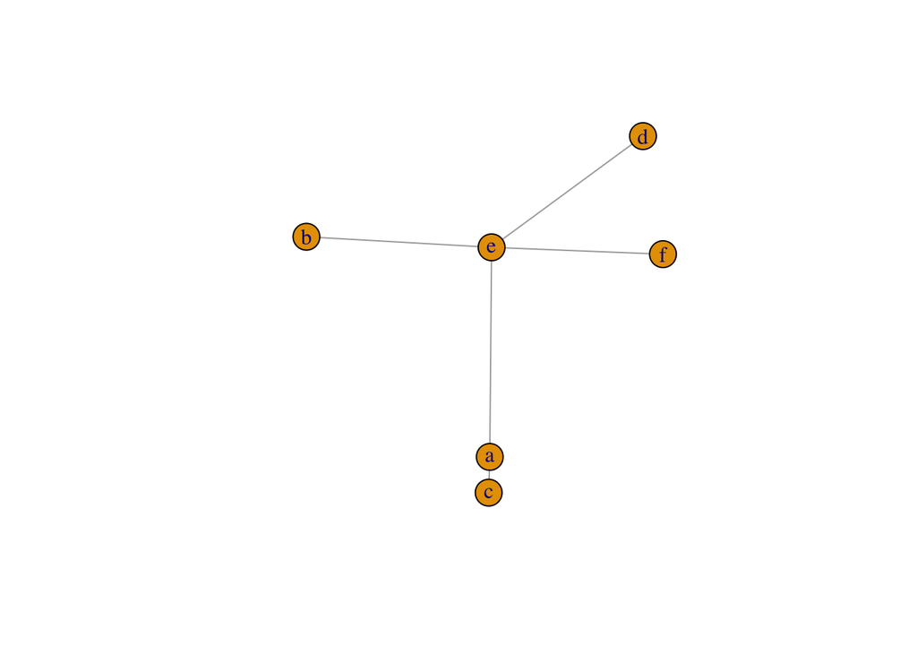

```r
plot(g, layout = layout.fruchterman.reingold,vertex.label=V(g)$number)
```

*Solutions*

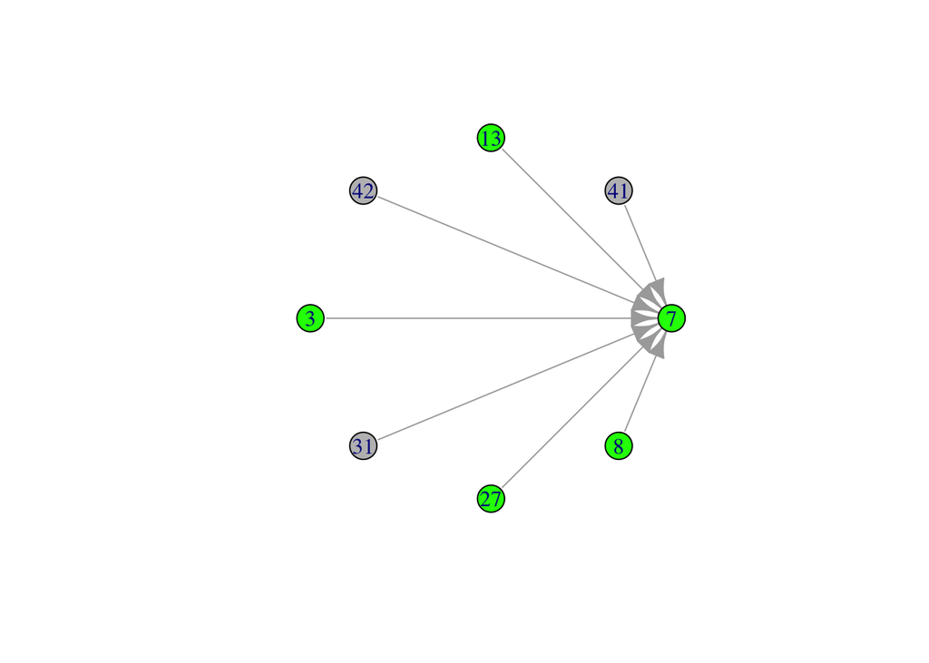

```r
g <- graph.star(8)

V(g)$number <- sample(1:50, vcount(g), replace=TRUE)

V(g)$color <- "grey"

V(g)[ number < 30 ]$color <- "green"

plot(g, layout=layout.circle, vertex.color=V(g)$color,

         vertex.label=V(g)$number)
```

*Solutions*

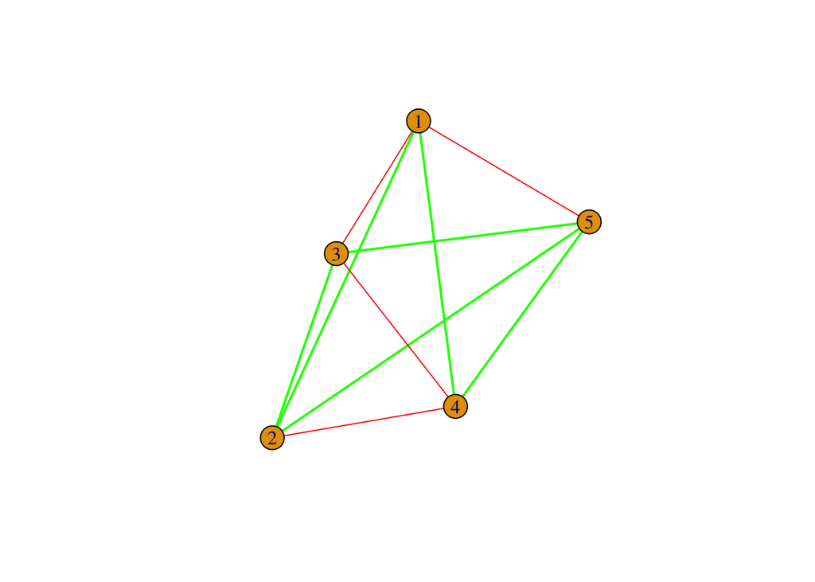

```r
g <- graph.full(5)

E(g)$weight <- runif(ecount(g))

E(g)$width <- 1

E(g)$color <- "red"

E(g)[ weight < 0.5 ]$width <- 2

E(g)[ weight < 0.5 ]$color <- "green"

plot(g)
```